# Homework 2

Brent Lewis

2023-05-23

# 1 Mass shootings in the US

```
## Rows: 125
## Columns: 14
## $ case                 <chr> "Oxford High School shooting", "San Jose VTA shoo…
## $ year                 <dbl> 2021, 2021, 2021, 2021, 2021, 2021, 2020, 2020, 2…
## $ month                <chr> "Nov", "May", "Apr", "Mar", "Mar", "Mar", "Mar", …
## $ day                  <dbl> 30, 26, 15, 31, 22, 16, 16, 26, 10, 6, 31, 4, 3, …
## $ location             <chr> "Oxford, Michigan", "San Jose, California", "Indi…
## $ summary              <chr> "Ethan Crumbley, a 15-year-old student at Oxford …
## $ fatalities           <dbl> 4, 9, 8, 4, 10, 8, 4, 5, 4, 3, 7, 9, 22, 3, 12, 5…
## $ injured              <dbl> 7, 0, 7, 1, 0, 1, 0, 0, 3, 8, 25, 27, 26, 12, 4, …
## $ total_victims        <dbl> 11, 9, 15, 5, 10, 9, 4, 5, 7, 11, 32, 36, 48, 15,…
## $ location_type        <chr> "School", "Workplace", "Workplace", "Workplace", …
## $ male                 <lgl> TRUE, TRUE, TRUE, TRUE, TRUE, TRUE, TRUE, TRUE, T…
## $ age_of_shooter       <dbl> 15, 57, 19, NA, 21, 21, 31, 51, NA, NA, 36, 24, 2…
## $ race                 <chr> NA, NA, "White", NA, NA, "White", NA, "Black", "B…
## $ prior_mental_illness <chr> NA, "Yes", "Yes", NA, "Yes", NA, NA, NA, NA, NA, …
```

| column(variable) | description |
| --- | --- |
| case | short name of incident |
| year, month, day | year, month, day in which the shooting occurred |
| location | city and state where the shooting occcurred |
| summary | brief description of the incident |
| fatalities | Number of fatalities in the incident, excluding the shooter |
| injured | Number of injured, non-fatal victims in the incident, excluding the shooter |
| total_victims | number of total victims in the incident, excluding the shooter |
| location_type | generic location in which the shooting took place |
| male | logical value, indicating whether the shooter was male |
| age_of_shooter | age of the shooter when the incident occured |
| race | race of the shooter |
| prior_mental_illness | did the shooter show evidence of mental illness prior to the incident? |

- Generate a data frame that summarizes the number of mass shootings per year.

```r
yearly_shootings_summary <- mass_shootings %>%
  group_by(year) %>%
  summarise(shootings=n()) %>%
  arrange(year)

print(yearly_shootings_summary)
```

```
## # A tibble: 37 × 2
##     year shootings
##    <dbl>     <int>
##  1  1982         1
##  2  1984         2
##  3  1986         1
##  4  1987         1
##  5  1988         1
##  6  1989         2
##  7  1990         1
##  8  1991         3
##  9  1992         2
## 10  1993         4
## # ℹ 27 more rows
```

```r
library(ggplot2)
# Extract race column. Since we will be converting this to a factor, it is best to create a new dataframe with just the required data
shooter_race <- mass_shootings %>%
  select(race) %>%
  filter(!is.na(race))

print(shooter_race)
```

```
## # A tibble: 114 × 1
##    race
##    <chr>
##  1 White
##  2 White
##  3 Black
##  4 Black
##  5 White
##  6 White
##  7 White
##  8 Black
##  9 Black
## 10 White
## # ℹ 104 more rows
```

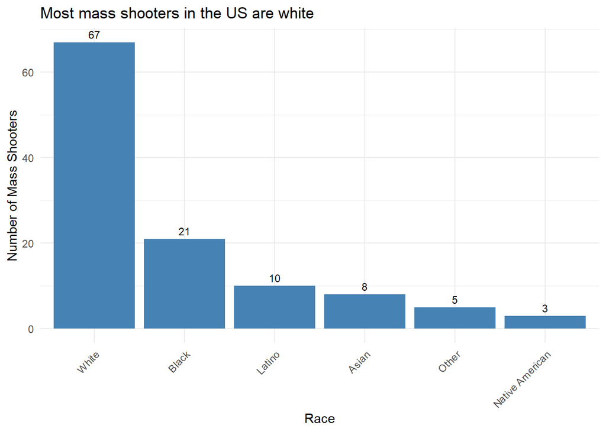

```r
# Convert race column to factor (this this is a categorical variable)
shooter_race$race <- as.factor(shooter_race$race)
# Count the number of mass shooters per race category
shooter_counts <- shooter_race %>%
  group_by(race) %>%
  summarize(Shooters = n()) %>%
  arrange(desc(Shooters))

ggplot(shooter_counts, aes(x = reorder(race, -Shooters), y = Shooters)) +
  geom_bar(stat = "identity", fill = "steelblue") +
  geom_text(aes(label = Shooters), vjust = -0.5, size = 3, color = "black") +  # Add data labels
  labs(x = "Race", y = "Number of Mass Shooters") +
  ggtitle("Most mass shooters in the US are white") +
  theme_minimal() +
  theme(axis.text.x = element_text(angle = 45, hjust = 1))
```

- Generate a boxplot visualizing the number of total victims, by type of location.

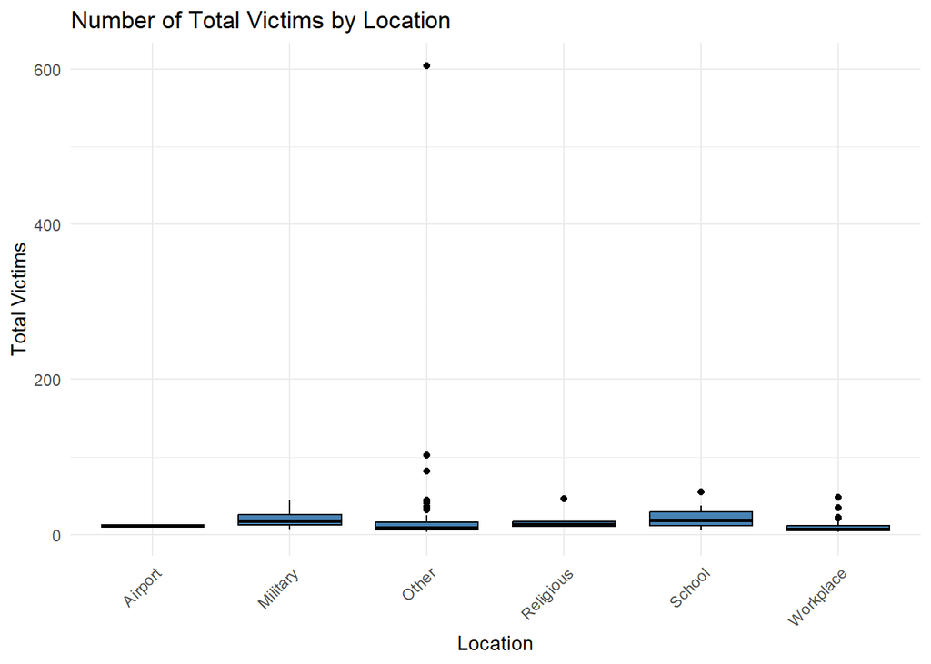

```r
ggplot(mass_shootings, aes(x = location_type, y = total_victims)) +
  geom_boxplot(fill = "steelblue", color = "black") +
  labs(x = "Location", y = "Total Victims") +
  ggtitle("Number of Total Victims by Location") +
  theme_minimal() +
  theme(axis.text.x = element_text(angle = 45, hjust = 1))
```

```r
# We can see that the outliers distort this graph and undermine its value
```

- Redraw the same plot, but remove the Las Vegas Strip massacre from the dataset.

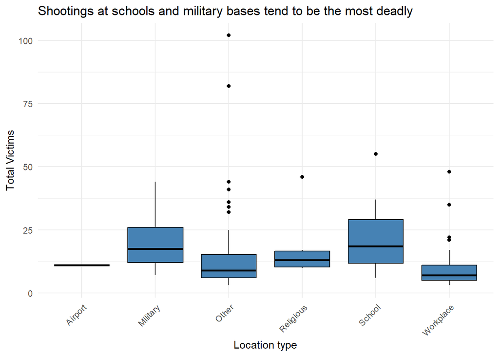

```r
mass_shootings %>%
  filter(case != "Las Vegas Strip massacre") %>%
  ggplot(aes(x = location_type, y = total_victims)) +
  geom_boxplot(fill = "steelblue", color = "black") +
  labs(x = "Location type", y = "Total Victims") +
  ggtitle("Shootings at schools and military bases tend to be the most deadly") +
  theme_minimal() +
  theme(axis.text.x = element_text(angle = 45, hjust = 1))
```

- How many white males with prior signs of mental illness initiated a mass shooting after 2000?

```r
library(dplyr)

# Filter the dataset for white males with prior signs of mental illness after 2000
white_males_with_mental_issues <- mass_shootings %>%
  filter(male == "TRUE" & race == "White" & prior_mental_illness == "Yes" & year >= 2000, na.rm=TRUE) %>%
  count(shooter = n())

# Print the result
print(paste("Number of white males with prior signs of mental illness initiating a mass shooting after 2000:", white_males_with_mental_issues))
```

```
## [1] "Number of white males with prior signs of mental illness initiating a mass shooting after 2000: 23"
## [2] "Number of white males with prior signs of mental illness initiating a mass shooting after 2000: 23"
```

- Which month of the year has the most mass shootings? Generate a bar chart sorted in chronological (natural) order (Jan-Feb-Mar- etc) to provide evidence of your answer.

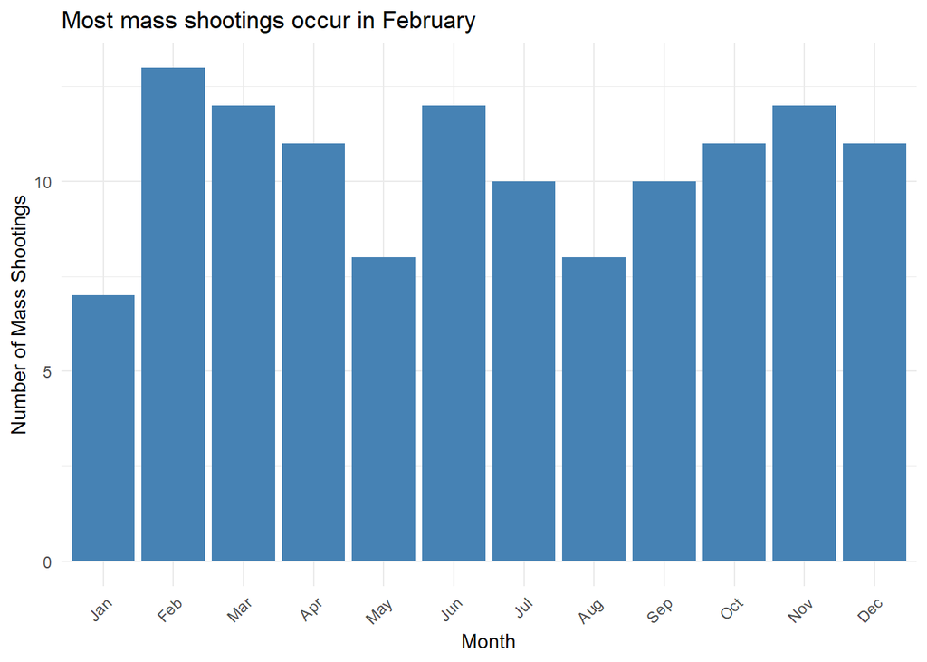

```r
library(lubridate)

# Count the number of mass shootings per month
shootings_per_month <- mass_shootings %>%
  group_by(month) %>%
  summarise(shootings = n()) %>%
  mutate(month_num = as.numeric(match(month, month.abb))) %>%
  mutate(month = fct_reorder(month, month_num, max)) %>%
  arrange(month_num) %>%
  ggplot(aes(x = month, y = shootings)) +
  geom_bar(stat = "identity", fill = "steelblue") +
  labs(x = "Month", y = "Number of Mass Shootings") +
  ggtitle("Most mass shootings occur in February") +
  theme_minimal() +
  theme(axis.text.x = element_text(angle = 45, hjust = 1))

print(shootings_per_month)
```

- How does the distribution of mass shooting fatalities differ between White and Black shooters? What about White and Latino shooters?

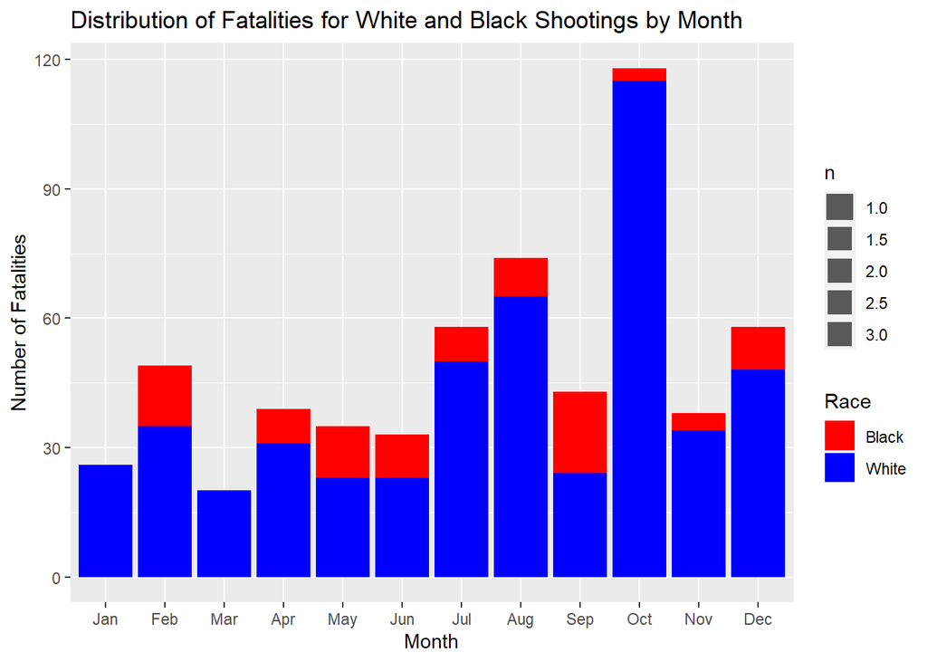

```r
library(ggplot2)

# Filter the data for white and black shooters
white_black_split <- mass_shootings %>%
  filter(race %in% c("White", "Black") & !is.na(race) & race != "Latino")  %>%
  mutate(month_num = as.numeric(match(month, month.abb))) %>%
  mutate(month = fct_reorder(month, month_num, max)) %>%
  select(race, fatalities, month, month_num)


# Create a bar plot to visualize the distribution
ggplot(white_black_split, aes(x = month, fill = race)) +
  geom_bar(position = "stack", stat = "sum", aes(y = fatalities)) +
  scale_fill_manual(values = c("White" = "blue", "Black" = "red")) +
  labs(x = "Month", y = "Number of Fatalities", fill = "Race") +
  ggtitle("Distribution of Fatalities for White and Black Shootings by Month")
```

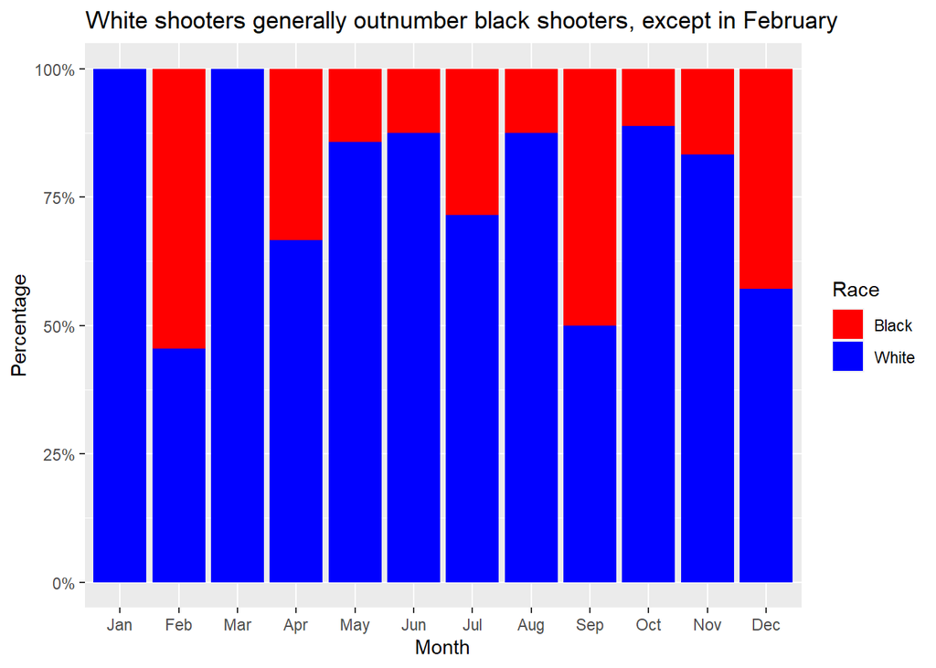

```r
# The bar chart below represents the racial breakdown of shooters between white and black
ggplot(white_black_split, aes(x = month, fill = race)) +
  geom_bar(position = "fill", aes(y = (..count..)/sum(..count..))) +
  scale_fill_manual(values = c("White" = "blue", "Black" = "red")) +
  labs(x = "Month", y = "Percentage", fill = "Race") +
  scale_y_continuous(labels = scales::percent_format(accuracy = 1)) +
  ggtitle("White shooters generally outnumber black shooters, except in February")
```

[figure not shown]

```r
# Recreate the code above, this time filtering for white and latino shooters and removing black shooters.
white_latino_split <- mass_shootings %>%
  filter(race %in% c("White", "Latino") & !is.na(race) & race != "Black")  %>%
  mutate(month_num = as.numeric(match(month, month.abb))) %>%
  mutate(month = fct_reorder(month, month_num, max))

# Create a bar plot to visualize the distribution
ggplot(white_latino_split, aes(x = month, fill = race)) +
  geom_bar(position = "stack", stat = "sum", aes(y = fatalities)) +
  scale_fill_manual(values = c("White" = "blue", "Latino" = "red")) +
  labs(x = "Month", y = "Number of Fatalities", fill = "Race") +
  ggtitle("Distribution of Fatalities for White and Black Shootings by Month")
```

- Are mass shootings with shooters suffering from mental illness different from mass shootings with no signs of mental illness in the shooter?

```r
# Filter the data for rows with known mental illness status
mass_shootings_with_illness <- mass_shootings[!is.na(mass_shootings$prior_mental_illness), ]

# Reshape the data into long format
reshaped_data <- pivot_longer(mass_shootings_with_illness, cols = c(fatalities, injured, total_victims),
                              names_to = "Variable", values_to = "Count")

print(reshaped_data)
```

```
## # A tibble: 237 × 13
##    case     year month   day location summary location_type male  age_of_shooter
##    <chr>   <dbl> <chr> <dbl> <chr>    <chr>   <chr>         <lgl>          <dbl>
##  1 San Jo…  2021 May      26 San Jos… "Samue… Workplace     TRUE              57
##  2 San Jo…  2021 May      26 San Jos… "Samue… Workplace     TRUE              57
##  3 San Jo…  2021 May      26 San Jos… "Samue… Workplace     TRUE              57
##  4 FedEx …  2021 Apr      15 Indiana… "Brand… Workplace     TRUE              19
##  5 FedEx …  2021 Apr      15 Indiana… "Brand… Workplace     TRUE              19
##  6 FedEx …  2021 Apr      15 Indiana… "Brand… Workplace     TRUE              19
##  7 Boulde…  2021 Mar      22 Boulder… "Ahmad… Workplace     TRUE              21
##  8 Boulde…  2021 Mar      22 Boulder… "Ahmad… Workplace     TRUE              21
##  9 Boulde…  2021 Mar      22 Boulder… "Ahmad… Workplace     TRUE              21
## 10 Odessa…  2019 Aug      31 Odessa,… "Seth … Other         TRUE              36
## # ℹ 227 more rows
## # ℹ 4 more variables: race <chr>, prior_mental_illness <chr>, Variable <chr>,
## #   Count <dbl>
```